# HeatMap

```python
    import matplotlib.pyplot as plt
```

[output not shown]

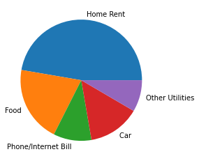

```python
exp_vals = [1400,600,300,410,250]
exp_labels = ["Home Rent","Food","Phone/Internet Bill","Car ","Other Utilities"]
plt.pie(exp_vals,labels = exp_labels)
```

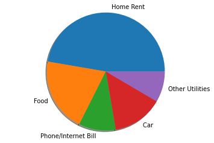

```python
plt.pie(exp_vals,labels = exp_labels, shadow = True)
plt.axis('equal')
plt.show()
```

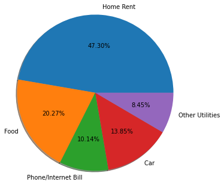

```python
plt.pie(exp_vals,labels = exp_labels,shadow = True, autopct = '%1.2f%%',radius = 1.5 )
plt.show()
```

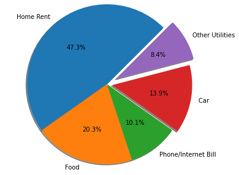

```python
plt.axis('equal')
plt.pie(exp_vals,labels = exp_labels,shadow = True, autopct = '%1.1f%%',radius= 1.5,explode = [0,0,0,0.1,0.2],counterclock = True,startangle = 45)
plt.show()
```

```python
import seaborn as sns
import pandas as pd
```

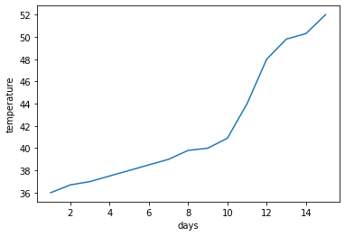

```python
days = [1,2,3,4,5,6,7,8,9,10,11,12,13,14,15]
temperature = [36,36.7,37,37.5,38,38.5,39,39.8,40,40.9,44,48,49.8,50.3,52]
temp_df = pd.DataFrame({'days':days,'temperature':temperature})
sns.lineplot(x = 'days',y = 'temperature',data = temp_df)
```

```python
tips_df.head()
```

|  | total_bill | tip | sex | smoker | day | time | size |
| --- | --- | --- | --- | --- | --- | --- | --- |
| 0 | 16.99 | 1.01 | Female | No | Sun | Dinner | 2 |
| 1 | 10.34 | 1.66 | Male | No | Sun | Dinner | 3 |
| 2 | 21.01 | 3.50 | Male | No | Sun | Dinner | 3 |
| 3 | 23.68 | 3.31 | Male | No | Sun | Dinner | 2 |
| 4 | 24.59 | 3.61 | Female | No | Sun | Dinner | 4 |

```python
tips_df =sns.load_dataset('tips')
tips_df
```

|  | total_bill | tip | sex | smoker | day | time | size |
| --- | --- | --- | --- | --- | --- | --- | --- |
| 0 | 16.99 | 1.01 | Female | No | Sun | Dinner | 2 |
| 1 | 10.34 | 1.66 | Male | No | Sun | Dinner | 3 |
| 2 | 21.01 | 3.50 | Male | No | Sun | Dinner | 3 |
| 3 | 23.68 | 3.31 | Male | No | Sun | Dinner | 2 |
| 4 | 24.59 | 3.61 | Female | No | Sun | Dinner | 4 |
| ... | ... | ... | ... | ... | ... | ... | ... |
| 239 | 29.03 | 5.92 | Male | No | Sat | Dinner | 3 |
| 240 | 27.18 | 2.00 | Female | Yes | Sat | Dinner | 2 |
| 241 | 22.67 | 2.00 | Male | Yes | Sat | Dinner | 2 |
| 242 | 17.82 | 1.75 | Male | No | Sat | Dinner | 2 |
| 243 | 18.78 | 3.00 | Female | No | Thur | Dinner | 2 |

244 rows × 7 columns

```python
tips_df.shape
```

```
(244, 7)
```

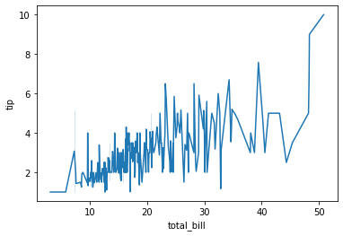

```python
sns.lineplot(x= 'total_bill',y = 'tip',data = tips_df)
```

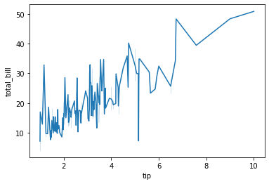

```python
sns.lineplot(x = 'tip',y= 'total_bill',data = tips_df)
```

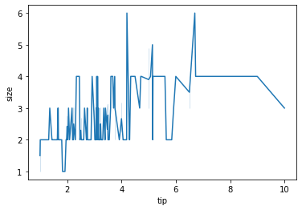

```python
 sns.lineplot(x = 'tip',y= 'size',data = tips_df)
```

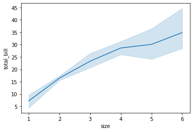

```python
 sns.lineplot(x = 'size',y= 'total_bill',data = tips_df)
```

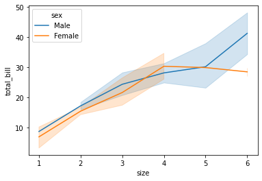

```python
 sns.lineplot(x = 'size',y= 'total_bill',data = tips_df,hue= 'sex')
```

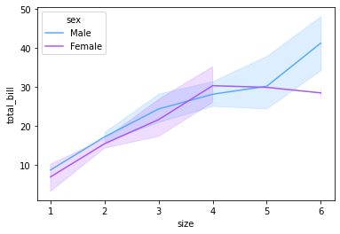

```python
 sns.lineplot(x = 'size',y= 'total_bill',data = tips_df,hue= 'sex',palette = 'cool')
```

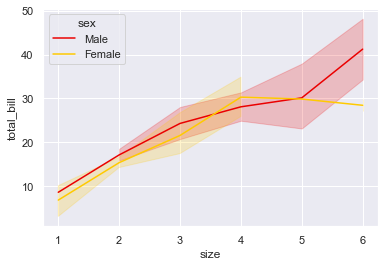

```python
sns.lineplot(x = 'size',y= 'total_bill',data = tips_df,hue= 'sex',palette = 'hot',markers = (['o','<']))
```

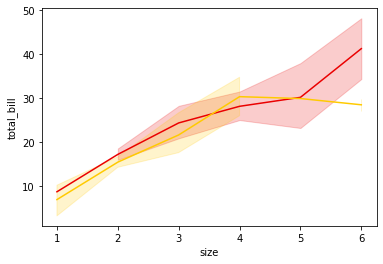

```python
sns.lineplot(x = 'size',y= 'total_bill',data = tips_df,hue= 'sex',palette = 'hot',markers =  ["o","<"],legend = False)
```

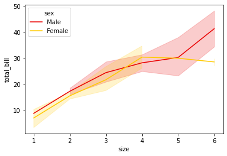

```python
sns.lineplot(x = 'size',y= 'total_bill',data = tips_df,hue= 'sex',palette = 'hot',markers =  ["o","<"],legend = 'brief')
plt.show()
```

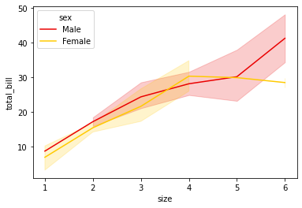

```python
sns.lineplot(x = 'size',y= 'total_bill',data = tips_df,hue= 'sex',palette = 'hot',markers =  ["o","<"],legend = 'brief')
plt.show()
```

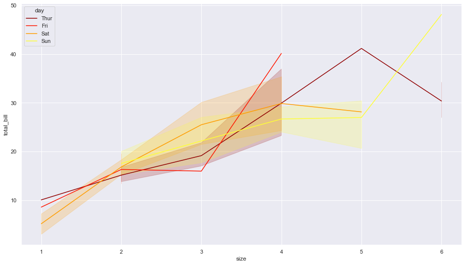

```python
plt.figure(figsize =(16,9) )
sns.set(style= 'darkgrid')
sns.lineplot(x = 'size',y= 'total_bill',data = tips_df,hue= 'day',palette = 'hot',markers =  ["o","<",">","*"],legend = 'brief')
plt.show()
```

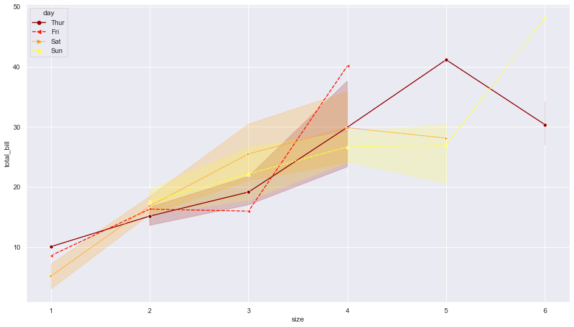

```python
plt.figure(figsize =(16,9) )
sns.set(style= 'darkgrid')
sns.lineplot(x = 'size',y= 'total_bill',data = tips_df,hue= 'day',style = 'day',palette = 'hot',markers =  ["o","<",">","^"],legend = 'brief')
plt.savefig('piechart.jpg')
plt.show()
```

# Keep in mind, mostly heatmap correlation use for feature selection from the dataset to build a Machine Learning model.

```python
import numpy as np
import pandas as pd
import matplotlib.pyplot as plt
import os
```

```python
arr_2 = np.linspace(1,5,12).reshape(4,3)
arr_2
```

```
array([[1.        , 1.36363636, 1.72727273],
       [2.09090909, 2.45454545, 2.81818182],
       [3.18181818, 3.54545455, 3.90909091],
       [4.27272727, 4.63636364, 5.        ]])
```

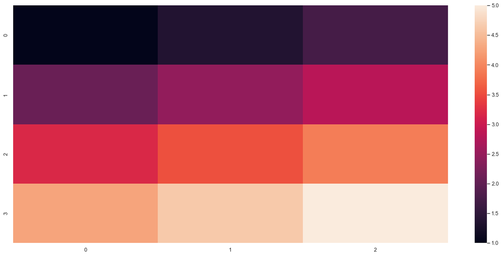

```python
plt.figure(figsize =(20,9))
sns.heatmap(arr_2)
```

```python
 tips_df =sns.load_dataset('tips')
tips_df
```

|  | total_bill | tip | sex | smoker | day | time | size |
| --- | --- | --- | --- | --- | --- | --- | --- |
| 0 | 16.99 | 1.01 | Female | No | Sun | Dinner | 2 |
| 1 | 10.34 | 1.66 | Male | No | Sun | Dinner | 3 |
| 2 | 21.01 | 3.50 | Male | No | Sun | Dinner | 3 |
| 3 | 23.68 | 3.31 | Male | No | Sun | Dinner | 2 |
| 4 | 24.59 | 3.61 | Female | No | Sun | Dinner | 4 |
| ... | ... | ... | ... | ... | ... | ... | ... |
| 239 | 29.03 | 5.92 | Male | No | Sat | Dinner | 3 |
| 240 | 27.18 | 2.00 | Female | Yes | Sat | Dinner | 2 |
| 241 | 22.67 | 2.00 | Male | Yes | Sat | Dinner | 2 |
| 242 | 17.82 | 1.75 | Male | No | Sat | Dinner | 2 |
| 243 | 18.78 | 3.00 | Female | No | Thur | Dinner | 2 |

244 rows × 7 columns

```python
tips_df.head()
```

[output not shown]

```python
tips_df.tail()
```

|  | total_bill | tip | sex | smoker | day | time | size |
| --- | --- | --- | --- | --- | --- | --- | --- |
| 239 | 29.03 | 5.92 | Male | No | Sat | Dinner | 3 |
| 240 | 27.18 | 2.00 | Female | Yes | Sat | Dinner | 2 |
| 241 | 22.67 | 2.00 | Male | Yes | Sat | Dinner | 2 |
| 242 | 17.82 | 1.75 | Male | No | Sat | Dinner | 2 |
| 243 | 18.78 | 3.00 | Female | No | Thur | Dinner | 2 |

```python
tips_df = tips_df.drop(['sex','smoker','day','time'],axis = 1)
tips_df
```

|  | total_bill | tip | size |
| --- | --- | --- | --- |
| 0 | 16.99 | 1.01 | 2 |
| 1 | 10.34 | 1.66 | 3 |
| 2 | 21.01 | 3.50 | 3 |
| 3 | 23.68 | 3.31 | 2 |
| 4 | 24.59 | 3.61 | 4 |
| ... | ... | ... | ... |
| 239 | 29.03 | 5.92 | 3 |
| 240 | 27.18 | 2.00 | 2 |
| 241 | 22.67 | 2.00 | 2 |
| 242 | 17.82 | 1.75 | 2 |
| 243 | 18.78 | 3.00 | 2 |

244 rows × 3 columns

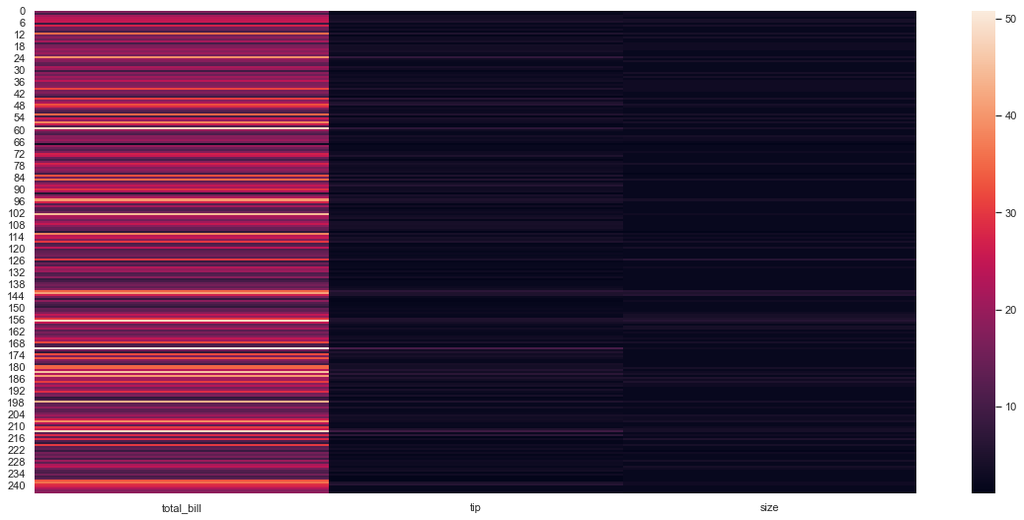

```python
#plt.figure(figsize=(9,6))
plt.figure(figsize =(20,9))
sns.heatmap(tips_df)
```

```python
globalWarming_df = pd.read_csv("Who_is_responsible_for_global_warming.csv")
globalWarming_df.head()
```

|  | Country Name | Country Code | Indicator Name | Indicator Code | 2000 | 2001 | 2002 | 2003 | 2004 | 2005 | 2006 | 2007 | 2008 | 2009 | 2010 | 2011 | 2012 | 2013 | 2014 |
| --- | --- | --- | --- | --- | --- | --- | --- | --- | --- | --- | --- | --- | --- | --- | --- | --- | --- | --- | --- |
| 0 | United States | USA | CO2 emissions (metric tons per capita) | EN.ATM.CO2E.PC | 20.178751 | 19.636505 | 19.613404 | 19.564105 | 19.658371 | 19.591885 | 19.094067 | 19.217898 | 18.461764 | 17.157738 | 17.442862 | 16.976957 | 16.310471 | 16.323477 | 16.502837 |
| 1 | United Kingdom | GBR | CO2 emissions (metric tons per capita) | EN.ATM.CO2E.PC | 9.199549 | 9.233175 | 8.904123 | 9.053278 | 8.989140 | 8.982939 | 8.898710 | 8.617164 | 8.424424 | 7.574622 | 7.857836 | 7.079298 | 7.355898 | 7.145844 | 6.497440 |
| 2 | India | IND | CO2 emissions (metric tons per capita) | EN.ATM.CO2E.PC | 0.979870 | 0.971698 | 0.967381 | 0.992392 | 1.025028 | 1.068563 | 1.121982 | 1.193210 | 1.310098 | 1.431844 | 1.397009 | 1.476686 | 1.598099 | 1.591438 | 1.730000 |
| 3 | China | CHN | CO2 emissions (metric tons per capita) | EN.ATM.CO2E.PC | 2.696862 | 2.742121 | 3.007083 | 3.524074 | 4.037991 | 4.523178 | 4.980314 | 5.334910 | 5.701915 | 6.010102 | 6.560520 | 7.241515 | 7.424751 | 7.557211 | 7.543908 |
| 4 | Russian Federation | RUS | CO2 emissions (metric tons per capita) | EN.ATM.CO2E.PC | 10.627121 | 10.669603 | 10.715901 | 11.090647 | 11.120627 | 11.253529 | 11.669122 | 11.672457 | 12.014507 | 11.023856 | 11.694348 | 12.334881 | 12.784979 | 12.393556 | 11.857528 |

```python
globalWarming_df  = globalWarming_df.drop(columns=['Country Code', 'Indicator Name', 'Indicator Code'], axis=1).set_index('Country Name')
globalWarming_df
```

| Country Name | 2000 | 2001 | 2002 | 2003 | 2004 | 2005 | 2006 | 2007 | 2008 | 2009 | 2010 | 2011 | 2012 | 2013 | 2014 |
| --- | --- | --- | --- | --- | --- | --- | --- | --- | --- | --- | --- | --- | --- | --- | --- |
| United States | 20.178751 | 19.636505 | 19.613404 | 19.564105 | 19.658371 | 19.591885 | 19.094067 | 19.217898 | 18.461764 | 17.157738 | 17.442862 | 16.976957 | 16.310471 | 16.323477 | 16.502837 |
| United Kingdom | 9.199549 | 9.233175 | 8.904123 | 9.053278 | 8.989140 | 8.982939 | 8.898710 | 8.617164 | 8.424424 | 7.574622 | 7.857836 | 7.079298 | 7.355898 | 7.145844 | 6.497440 |
| India | 0.979870 | 0.971698 | 0.967381 | 0.992392 | 1.025028 | 1.068563 | 1.121982 | 1.193210 | 1.310098 | 1.431844 | 1.397009 | 1.476686 | 1.598099 | 1.591438 | 1.730000 |
| China | 2.696862 | 2.742121 | 3.007083 | 3.524074 | 4.037991 | 4.523178 | 4.980314 | 5.334910 | 5.701915 | 6.010102 | 6.560520 | 7.241515 | 7.424751 | 7.557211 | 7.543908 |
| Russian Federation | 10.627121 | 10.669603 | 10.715901 | 11.090647 | 11.120627 | 11.253529 | 11.669122 | 11.672457 | 12.014507 | 11.023856 | 11.694348 | 12.334881 | 12.784979 | 12.393556 | 11.857528 |
| Australia | 17.200610 | 16.733367 | 17.370452 | 16.901959 | 17.026515 | 17.169711 | 17.651398 | 17.865260 | 18.160876 | 18.200182 | 17.740845 | 17.538878 | 17.072905 | 16.095833 | 15.388766 |
| France | 5.946665 | 6.153061 | 6.068664 | 6.115998 | 6.120079 | 6.099599 | 5.906266 | 5.766385 | 5.690501 | 5.438357 | 5.428981 | 5.077911 | 5.075064 | 5.062174 | 4.573182 |
| Germany | 10.095640 | 10.366287 | 10.058673 | 9.969355 | 9.898682 | 9.666372 | 9.911476 | 9.488040 | 9.506321 | 8.818596 | 9.279634 | 9.124859 | 9.199300 | 9.390623 | 8.889370 |
| Canada | 17.367115 | 16.985030 | 16.559378 | 17.461199 | 17.258911 | 17.251083 | 16.696694 | 16.855883 | 16.875198 | 15.961560 | 15.723167 | 15.639760 | 14.890636 | 14.711972 | 15.117159 |
| Brazil | 1.871118 | 1.898354 | 1.844380 | 1.762482 | 1.828672 | 1.858088 | 1.839394 | 1.901372 | 2.008670 | 1.883812 | 2.132938 | 2.211587 | 2.343570 | 2.488417 | 2.594388 |
| Argentina | 3.835574 | 3.568600 | 3.291548 | 3.525584 | 4.069058 | 4.141237 | 4.434821 | 4.382669 | 4.682912 | 4.410890 | 4.558500 | 4.600291 | 4.569384 | 4.462904 | 4.746797 |
| Pakistan | 0.768458 | 0.764702 | 0.788668 | 0.804959 | 0.872802 | 0.887768 | 0.929857 | 0.991030 | 0.972050 | 0.950832 | 0.946268 | 0.929801 | 0.918978 | 0.904316 | 0.896264 |
| Nepal | 0.129282 | 0.135226 | 0.106877 | 0.113902 | 0.105477 | 0.120277 | 0.098812 | 0.099736 | 0.129224 | 0.162087 | 0.187128 | 0.202491 | 0.211798 | 0.237170 | 0.283539 |
| Bangladesh | 0.211802 | 0.242020 | 0.246756 | 0.256602 | 0.266823 | 0.275247 | 0.299529 | 0.301631 | 0.332728 | 0.357159 | 0.393937 | 0.412011 | 0.433488 | 0.442401 | 0.459142 |
| Japan | 9.622352 | 9.464309 | 9.573130 | 9.725282 | 9.909203 | 9.698883 | 9.632049 | 9.782964 | 9.449534 | 8.620816 | 9.148316 | 9.317427 | 9.638628 | 9.780815 | 9.538706 |

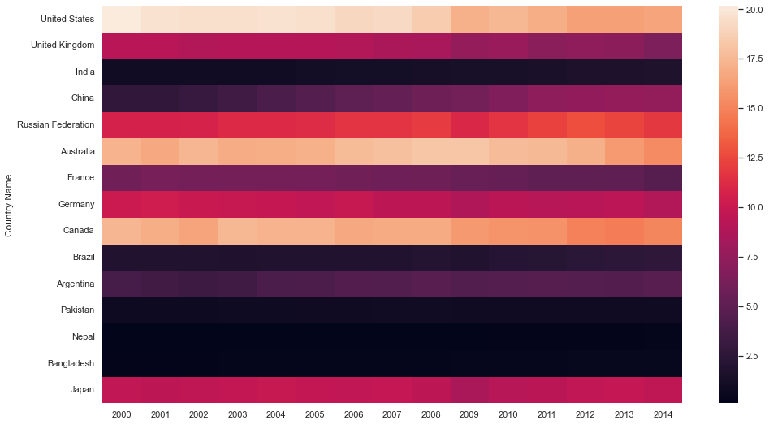

```python
plt.figure(figsize=(16,9))

sns.heatmap(globalWarming_df)
```

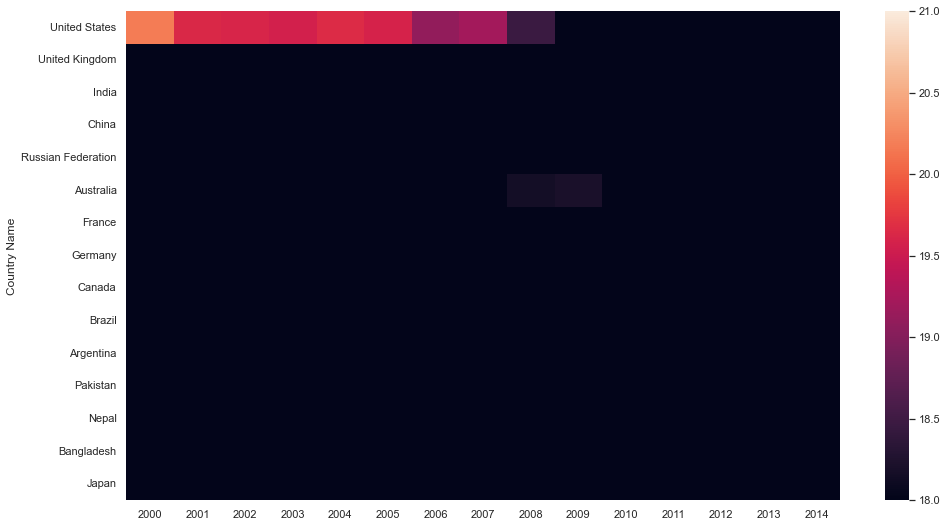

```python
plt.figure(figsize=(16,9))

sns.heatmap(globalWarming_df, vmin = 18, vmax = 21)
```

How to change seaborn heatmap color using cmap parameter?

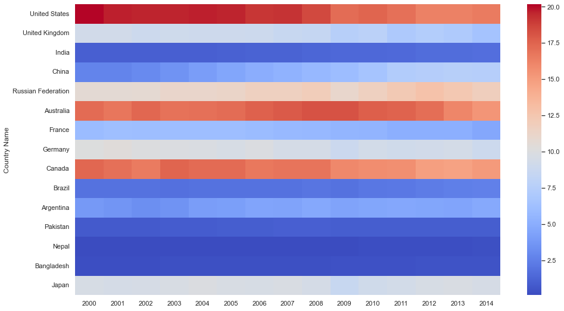

```python
# change heatmap color using cmap

plt.figure(figsize=(16,9))

sns.heatmap(globalWarming_df, cmap="coolwarm")
```

Change cmap using sns.heatmap() center parameter

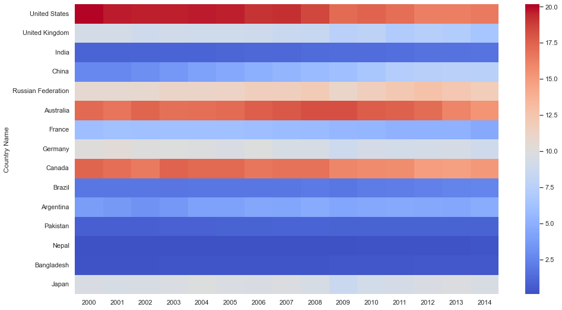

```python
# center parameter

plt.figure(figsize=(16,9))

sns.heatmap(globalWarming_df, cmap="coolwarm", center = 10.0)
```

How to remove vmin or vmax using sns.heatmap() robust parameter? To remove the vmin or vmax or both from the color bar, pass ‘True‘ value to sns heatmap robust parameter. Then the colormap range is computed with robust quantiles instead of the extreme values.

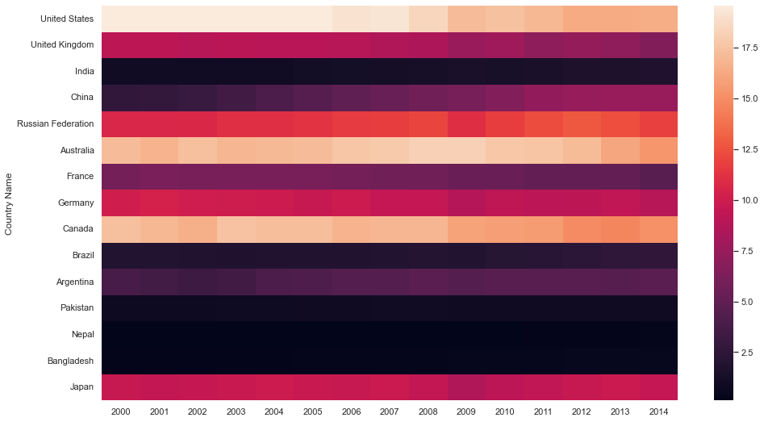

```python
# robust

plt.figure(figsize=(16,9))

sns.heatmap(globalWarming_df, robust = True)
```

Seaborn heatmap annot parameter – add a number on each cell When we pass bool ‘True‘ value to annot then the value will show on each cell of the heatmap.

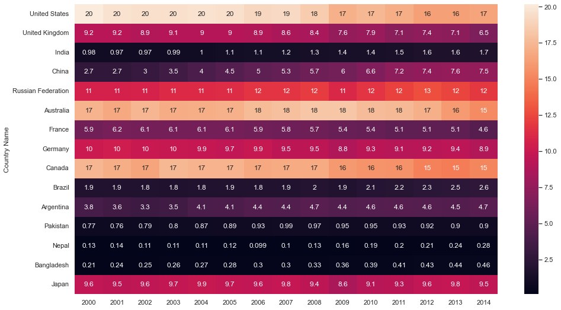

```python
# annot (annotate) parameter

plt.figure(figsize=(16,9))

sns.heatmap(globalWarming_df, annot = True)
```

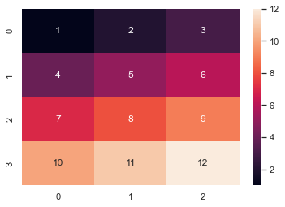

```python
# pass 2D Numpy array to annot parameter

annot_arr = np.arange(1,13).reshape(4,3) # create 2D numpy array with 4 rows and 3 columns

sns.heatmap(annot_arr, annot= annot_arr)
```

How to change style & format of annot (annotate) using sns.heatmap() annot_kws Here, we are passing some annotate keyword arguments but you can pass all ax.text or matplotlib.text arguments.

fontsize: To change the size of the font fontstyle: To change the style of font like italic, oblique and normal fontfamily: To change the family of font like serif, cursive color: To change the color of font alpha: To change the transparency of the text rotation: To change the rotation of the text verticalalignment: To change the vertical alignment of the text like center, top, bottom, baseline, center_baseline backgroundcolor: To change the background color of the text

While passing annot_kws then annot value must be True.

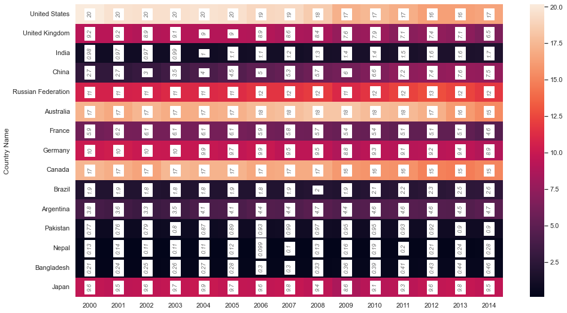

```python
# annot_kws parameter

plt.figure(figsize=(16,9))

annot_kws={'fontsize':10,
           'fontstyle':'italic',
           'color':"k",
           'alpha':0.6,
           'rotation':"vertical",
           'verticalalignment':'center',
           'backgroundcolor':'w'}

sns.heatmap(globalWarming_df, annot = True, annot_kws= annot_kws)
```

Separate each cell of a heatmap using sns.heatmap() linewidths parameter

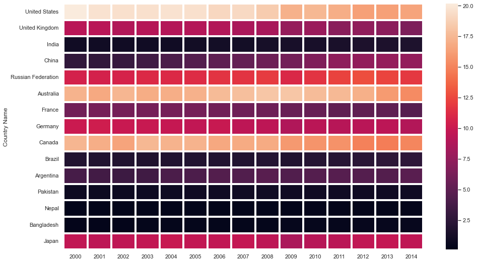

```python
# linewidths parameter - divede each cell of heatmap

plt.figure(figsize=(16,9))

sns.heatmap(globalWarming_df, linewidths=4)
```

Change the line color of seaborn heatmap with linecolor parameter

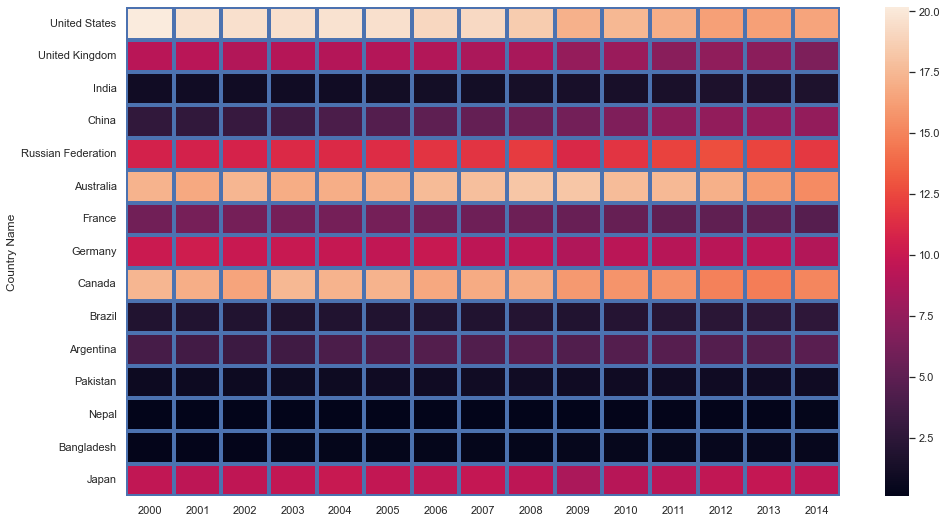

```python
# linecolor parameter - change the color of heatmap line

plt.figure(figsize=(16,9))

sns.heatmap(globalWarming_df, linewidths=4, linecolor="b")
```

How to hide color bar using sns.heatmap() cbar parameter?

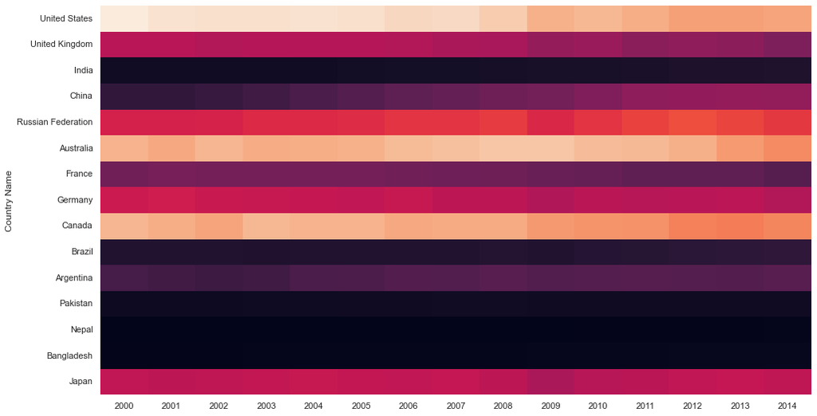

```python
# hide color bar with cbar parameter

plt.figure(figsize=(16,9))

sns.heatmap(globalWarming_df, cbar = False)
```